```r
options(rpubs.upload.method = "internal")
options(RCurlOptions = list(verbose = FALSE, capath = system.file("CurlSSL", "cacert.pem", package = "RCurl"), ssl.verifypeer = FALSE))
```

```r
library(knitr)
opts_chunk$set(echo=TRUE, cache=FALSE)
```

## Impacts of Storms on People and Property

### Synopsis

An analysis was done of the NOAA Storm Event dataset, the top ten most damaging events for the economy (property and crops) and human health were computed and plotted. The primary questions were:

1. Across the United States, which types of Storm events are most harmful with respect to population health?
2. Across the United States, which types of Storm events have the greatest economic consequences?

#### Dataset Overview

- The URL for the dataset is https://d396qusza40orc.cloudfront.net/repdata%2Fdata%2FStormData.csv.bz2
- The documentation for the dataset can be found at: https://d396qusza40orc.cloudfront.net/repdata%2Fpeer2_doc%2Fpd01016005curr.pdf

#### Overview of Data Analysis

- We looked at the EVTYPE column to determine the Event type as well as the FATALITIES and the INJURIES to understand the effect of the storm on human health.
- We looked at the PROPDAMAGE as well we the PROPEMGEXP (explains currency level ex: K=1000)as well as the CROPDMG and CROPDMGEXP to determine the effect of the storm event on the economy.
- We then computed the top 10 storm impacts on the health by a sum of fatalities and injuries and the economy as measured by property and crop damage.

### Data Processing

The following libraries were loaded:

```r
library(data.table)
library(dplyr)
library(plyr)
```

```r
library(ggplot2)
library(xtable)
```

```r
options(rpubs.upload.method = "internal")
```

#### Data Pre-Processing

###### Steps followed:

- Download the file and select only the relevant columns for the analysis
- Sum the Fatalities and Injuries to total the human impact
- Compute the dollar impact on property and crops using damage and damage exponent columns.
- Sum the Property and Crop damage to total property damage.
- Select top ten damage impacts for Health and Property.

Note:

The following is the code used to download and process the file on a local machine. + Set the working directory, download the file, read in only needed columns:

download.file(“https://d396qusza40orc.cloudfront.net/repdata%2Fdata%2FStormData.csv.bz2”,“storm.csv.bz2”)

1. Unpack file to load into R dataset. Note: Going to get a cup of coffee/tea would not be a bad idea.

```r
## download.file("https://d396qusza40orc.cloudfront.net/repdata%2Fdata%2FStormData.csv.bz2","storm.csv.bz2")
setwd( "C:/Alison/R/R Working Directory")
stormdata<- read.csv(bzfile("storm.csv.bz2"), header=TRUE, stringsAsFactors=FALSE)[,c("EVTYPE","FATALITIES","INJURIES","PROPDMG","PROPDMGEXP","CROPDMG","CROPDMGEXP")]
```

2. Sum the Fatalities and Injuries to Total Health Impact

```r
storm.data <- mutate(stormdata,Health = FATALITIES + INJURIES)
```

3. Determine the exponents to convert

```r
unique(storm.data$PROPDMGEXP)
```

```
##  [1] "K" "M" ""  "B" "m" "+" "0" "5" "6" "?" "4" "2" "3" "h" "7" "H" "-"
## [18] "1" "8"
```

```r
rm(stormdata)
```

4. Transform the character values to numbers.

```r
storm.data$PROPDMGEXP[storm.data$PROPDMGEXP == "H"] <- 100
storm.data$PROPDMGEXP[storm.data$PROPDMGEXP == "K"] <- 1000
storm.data$PROPDMGEXP[storm.data$PROPDMGEXP == "M"] <- 1000000
storm.data$PROPDMGEXP[storm.data$PROPDMGEXP == "B"] <- 1000000000
storm.data$PROPDMGEXP[storm.data$PROPDMGEXP == "h"] <- 100
storm.data$PROPDMGEXP[storm.data$PROPDMGEXP == "m"] <- 1000
storm.data$PROPDMGEXP[storm.data$PROPDMGEXP == "b"] <- 1000000000
storm.data$PROPDMGEXP[storm.data$PROPDMGEXP == ""] <- 1
storm.data$PROPDMGEXP[storm.data$PROPDMGEXP == "?"] <- 1
storm.data$PROPDMGEXP[storm.data$PROPDMGEXP == "-"] <- 1
storm.data$PROPDMGEXP[storm.data$PROPDMGEXP == "+"] <- 1
storm.data$PROPDMGEXP[storm.data$PROPDMGEXP == "2"] <- 100
storm.data$PROPDMGEXP[storm.data$PROPDMGEXP == "3"] <- 1000
storm.data$PROPDMGEXP[storm.data$PROPDMGEXP == "4"] <- 10000
storm.data$PROPDMGEXP[storm.data$PROPDMGEXP == "5"] <- 100000
storm.data$PROPDMGEXP[storm.data$PROPDMGEXP == "6"] <- 1000000
storm.data$PROPDMGEXP[storm.data$PROPDMGEXP == "7"] <- 10000000
storm.data$PROPDMGEXP[storm.data$PROPDMGEXP == "8"] <- 100000000

## Repeat for CROPDMGEXP

storm.data$CROPDMGEXP[storm.data$CROPDMGEXP == "H"] <- 100
storm.data$CROPDMGEXP[storm.data$CROPDMGEXP == "K"] <- 1000
storm.data$CROPDMGEXP[storm.data$CROPDMGEXP == "M"] <- 1000000
storm.data$CROPDMGEXP[storm.data$CROPDMGEXP == "B"] <- 1000000000
storm.data$CROPDMGEXP[storm.data$CROPDMGEXP == "h"] <- 100
storm.data$CROPDMGEXP[storm.data$CROPDMGEXP == "m"] <- 1000
storm.data$CROPDMGEXP[storm.data$CROPDMGEXP == "b"] <- 1000000000
storm.data$CROPDMGEXP[storm.data$CROPDMGEXP == ""] <- 1
storm.data$CROPDMGEXP[storm.data$CROPDMGEXP == "?"] <- 1
storm.data$CROPDMGEXP[storm.data$CROPDMGEXP == "-"] <- 1
storm.data$CROPDMGEXP[storm.data$CROPDMGEXP == "+"] <- 1
storm.data$CROPDMGEXP[storm.data$CROPDMGEXP == "2"] <- 100
storm.data$CROPDMGEXP[storm.data$CROPDMGEXP == "3"] <- 1000
storm.data$CROPDMGEXP[storm.data$CROPDMGEXP == "4"] <- 10000
storm.data$CROPDMGEXP[storm.data$CROPDMGEXP == "5"] <- 100000
storm.data$CROPDMGEXP[storm.data$CROPDMGEXP == "6"] <- 1000000
storm.data$CROPDMGEXP[storm.data$CROPDMGEXP == "7"] <- 10000000
storm.data$CROPDMGEXP[storm.data$CROPDMGEXP == "8"] <- 100000000
storm.data$CROPDMGEXP[is.na(storm.data$CROPDMGEXP)] <- 0
```

5. Clean up all the missing values (NA) and convert the test numbers to numeric fields to allow for calculations.

```r
##  Set to numeric, set NAs to 0
storm.data$CROPDMGEXP <-as.numeric(storm.data$CROPDMGEXP)
storm.data$PROPDMGEXP <-as.numeric(storm.data$PROPDMGEXP)
storm.data$CROPDMGEXP[is.na(storm.data$CROPDMGEXP)] <- 0
storm.data$PROPDMG[is.na(storm.data$PROPDMGEXP)] <- 0
storm.data$CROPDMG <-as.numeric(storm.data$CROPDMG)
storm.data$PROPDMG<-as.numeric(storm.data$PROPDMG)
storm.data$CROPDMG[is.na(storm.data$CROPDMG)] <- 0
storm.data$PROPDMG[is.na(storm.data$PROPDMG)] <- 0
```

```r
## Create new calculated columns for Property and Crop Damage and Total Economic Damage
storm.data <- mutate(storm.data,Prop.Damage =  PROPDMGEXP * PROPDMG)
storm.data <- mutate(storm.data,Crop.Damage =  CROPDMGEXP * CROPDMG)
storm.data <- mutate(storm.data,Total.Damage = Prop.Damage + Crop.Damage)
storm.data.prop <- ddply(storm.data, "EVTYPE", summarise, Total.Damage = sum(Total.Damage))
storm.data.prop.mill <- mutate(storm.data.prop, Total.Dollars = Total.Damage / 100000000)
storm.data.health <- ddply(storm.data, "EVTYPE", summarise, Health = sum(Health))

rm(storm.data)
```

### Results

7. Find the Top 10 Storm Data for Property.

```r
storm.data.prop.mill <-storm.data.prop.mill[rev(order(storm.data.prop.mill$Total.Dollar)),]
top.property <-head(storm.data.prop.mill,10)
colnames(top.property) <- c("Storm.Event", "Total.Dollars", "Total.Dollars.Millions")
top.property
```

```
##           Storm.Event Total.Dollars Total.Dollars.Millions
## 170             FLOOD  150319678257             1503.19678
## 411 HURRICANE/TYPHOON   71913712800              719.13713
## 834           TORNADO   57350845153              573.50845
## 670       STORM SURGE   43323541000              433.23541
## 244              HAIL   18755909630              187.55910
## 153       FLASH FLOOD   18243990817              182.43991
## 95            DROUGHT   15018672000              150.18672
## 402         HURRICANE   14610229010              146.10229
## 590       RIVER FLOOD   10148404500              101.48404
## 427         ICE STORM    8967041310               89.67041
```

8. Find the Top 10 Storm Data for Health.

```r
storm.data.health <-storm.data.health[rev(order(storm.data.health$Health)),]
top.health <-head(storm.data.health,10)
colnames(top.health) <- c("Storm.Event", "Persons.Impacted")
top.health
```

```
##           Storm.Event Persons.Impacted
## 834           TORNADO            96979
## 130    EXCESSIVE HEAT             8428
## 856         TSTM WIND             7461
## 170             FLOOD             7259
## 464         LIGHTNING             6046
## 275              HEAT             3037
## 153       FLASH FLOOD             2755
## 427         ICE STORM             2064
## 760 THUNDERSTORM WIND             1621
## 972      WINTER STORM             1527
```

```r
rm(storm.data.prop)
```

#### Plots

1. Plot the Storm Damage for Health Impact

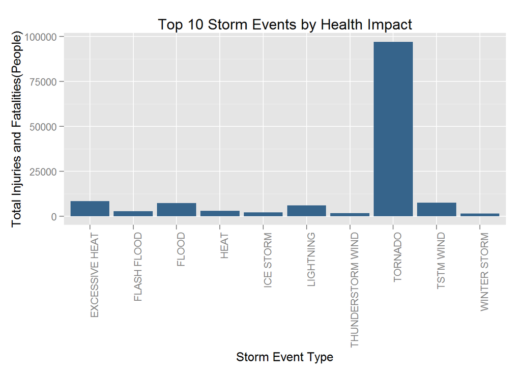

```r
## Plot the Storm Damage for Health
    par(mar = c(5,4,1,1),las=1)
    ggplot(data=top.health, aes(x=Storm.Event, y=Persons.Impacted)) +
    geom_bar(stat="identity",fill="steelblue4") +
    labs(x= "Storm Event Type") +
    labs(y= "Total Injuries and Fatalities(People)") +
    labs(title= "Top 10 Storm Events by Health Impact") +
    theme(axis.text.x = element_text(angle = 90, hjust = 1))
```

```r
TopHealth <- top.health$Storm.Event[1]
```

##### The most serious storm damage on human health as computed by summing the total fatalities and injuries is caused by TORNADO.

2. Plot the Storm Damage for Property Impact

[figure not shown]

```r
    par(mar = c(5,4,1,2),las=1)
    ggplot(data=top.property, aes(x=Storm.Event, y=Total.Dollars.Millions)) +
    geom_bar(stat="identity",fill="steelblue4") +
    labs(x= "Storm Event Type") +
    labs(y= "Total Dollar Impact(Million $)") +
    labs(title= "Top 10 Storm Events by Property and Crop Damage Impact") +
    theme(axis.text.x = element_text(angle = 90, hjust = 1))
```

```r
TopProp <- top.property$Storm.Event[1]
```

### Summary/Abstract

An analysis was done of the NOAA Storm Event dataset, the top ten most damaging events for the economy (property and crops) and human health were computed and plotted. The most damaging econmic event was found to be FLOOD(s) and the top most damaging event on human life/health was found to be TORNADO(s).

```r
setwd("C:/Users/adoucette/Documents")
```